# Risk Factor Analysis

## Outcome Variable

**Outcome Variable:** ever_stunted

## Predictor Variables

**Intervention Variable:** lag_WHZ_quart

**Adjustment Set:**

- arm
- sex
- W_mage
- meducyrs
- feducyrs
- single
- month
- brthmon
- delta_W_mage
- delta_meducyrs
- delta_feducyrs
- delta_single
- delta_month
- delta_brthmon

## Stratifying Variables

The analysis was stratified on these variable(s):

- agecat
- studyid
- country

## Data Summary

| agecat | studyid | country | lag_WHZ_quart | ever_stunted | n_cell | n |
| --- | --- | --- | --- | --- | --- | --- |
| 3-6 months | ki0047075b-MAL-ED | BANGLADESH | 1 | 0 | 39 | 207 |
| 3-6 months | ki0047075b-MAL-ED | BANGLADESH | 1 | 1 | 5 | 207 |
| 3-6 months | ki0047075b-MAL-ED | BANGLADESH | 2 | 0 | 81 | 207 |
| 3-6 months | ki0047075b-MAL-ED | BANGLADESH | 2 | 1 | 15 | 207 |
| 3-6 months | ki0047075b-MAL-ED | BANGLADESH | 3 | 0 | 52 | 207 |
| 3-6 months | ki0047075b-MAL-ED | BANGLADESH | 3 | 1 | 7 | 207 |
| 3-6 months | ki0047075b-MAL-ED | BANGLADESH | 4 | 0 | 7 | 207 |
| 3-6 months | ki0047075b-MAL-ED | BANGLADESH | 4 | 1 | 1 | 207 |
| 3-6 months | ki0047075b-MAL-ED | BRAZIL | 1 | 0 | 32 | 201 |
| 3-6 months | ki0047075b-MAL-ED | BRAZIL | 1 | 1 | 1 | 201 |
| 3-6 months | ki0047075b-MAL-ED | BRAZIL | 2 | 0 | 89 | 201 |
| 3-6 months | ki0047075b-MAL-ED | BRAZIL | 2 | 1 | 5 | 201 |
| 3-6 months | ki0047075b-MAL-ED | BRAZIL | 3 | 0 | 52 | 201 |
| 3-6 months | ki0047075b-MAL-ED | BRAZIL | 3 | 1 | 3 | 201 |
| 3-6 months | ki0047075b-MAL-ED | BRAZIL | 4 | 0 | 15 | 201 |
| 3-6 months | ki0047075b-MAL-ED | BRAZIL | 4 | 1 | 4 | 201 |
| 3-6 months | ki0047075b-MAL-ED | INDIA | 1 | 0 | 66 | 199 |
| 3-6 months | ki0047075b-MAL-ED | INDIA | 1 | 1 | 13 | 199 |
| 3-6 months | ki0047075b-MAL-ED | INDIA | 2 | 0 | 64 | 199 |
| 3-6 months | ki0047075b-MAL-ED | INDIA | 2 | 1 | 10 | 199 |
| 3-6 months | ki0047075b-MAL-ED | INDIA | 3 | 0 | 30 | 199 |
| 3-6 months | ki0047075b-MAL-ED | INDIA | 3 | 1 | 9 | 199 |
| 3-6 months | ki0047075b-MAL-ED | INDIA | 4 | 0 | 4 | 199 |
| 3-6 months | ki0047075b-MAL-ED | INDIA | 4 | 1 | 3 | 199 |
| 3-6 months | ki0047075b-MAL-ED | NEPAL | 1 | 0 | 46 | 210 |
| 3-6 months | ki0047075b-MAL-ED | NEPAL | 1 | 1 | 0 | 210 |
| 3-6 months | ki0047075b-MAL-ED | NEPAL | 2 | 0 | 79 | 210 |
| 3-6 months | ki0047075b-MAL-ED | NEPAL | 2 | 1 | 2 | 210 |
| 3-6 months | ki0047075b-MAL-ED | NEPAL | 3 | 0 | 67 | 210 |
| 3-6 months | ki0047075b-MAL-ED | NEPAL | 3 | 1 | 3 | 210 |

[output cut: 882 more lines]

The following strata were considered:

- agecat: 12-15 months, studyid: ki0047075b-MAL-ED, country: BANGLADESH
- agecat: 12-15 months, studyid: ki0047075b-MAL-ED, country: BRAZIL
- agecat: 12-15 months, studyid: ki0047075b-MAL-ED, country: INDIA
- agecat: 12-15 months, studyid: ki0047075b-MAL-ED, country: NEPAL
- agecat: 12-15 months, studyid: ki0047075b-MAL-ED, country: PERU
- agecat: 12-15 months, studyid: ki0047075b-MAL-ED, country: SOUTH AFRICA
- agecat: 12-15 months, studyid: ki0047075b-MAL-ED, country: TANZANIA, UNITED REPUBLIC OF
- agecat: 12-15 months, studyid: ki1000108-CMC-V-BCS-2002, country: INDIA
- agecat: 12-15 months, studyid: ki1000108-IRC, country: INDIA
- agecat: 12-15 months, studyid: ki1000109-EE, country: PAKISTAN
- agecat: 12-15 months, studyid: ki1017093b-PROVIDE, country: BANGLADESH
- agecat: 12-15 months, studyid: ki1066203-TanzaniaChild2, country: TANZANIA, UNITED REPUBLIC OF
- agecat: 12-15 months, studyid: ki1101329-Keneba, country: GAMBIA
- agecat: 12-15 months, studyid: ki1112895-Guatemala BSC, country: GUATEMALA
- agecat: 12-15 months, studyid: ki1113344-GMS-Nepal, country: NEPAL
- agecat: 12-15 months, studyid: ki1114097-CMIN, country: BANGLADESH
- agecat: 12-15 months, studyid: ki1114097-CMIN, country: PERU
- agecat: 15-18 months, studyid: ki0047075b-MAL-ED, country: BANGLADESH
- agecat: 15-18 months, studyid: ki0047075b-MAL-ED, country: BRAZIL
- agecat: 15-18 months, studyid: ki0047075b-MAL-ED, country: INDIA
- agecat: 15-18 months, studyid: ki0047075b-MAL-ED, country: NEPAL
- agecat: 15-18 months, studyid: ki0047075b-MAL-ED, country: PERU
- agecat: 15-18 months, studyid: ki0047075b-MAL-ED, country: SOUTH AFRICA
- agecat: 15-18 months, studyid: ki0047075b-MAL-ED, country: TANZANIA, UNITED REPUBLIC OF
- agecat: 15-18 months, studyid: ki1000108-CMC-V-BCS-2002, country: INDIA
- agecat: 15-18 months, studyid: ki1000108-IRC, country: INDIA
- agecat: 15-18 months, studyid: ki1000109-EE, country: PAKISTAN
- agecat: 15-18 months, studyid: ki1017093b-PROVIDE, country: BANGLADESH
- agecat: 15-18 months, studyid: ki1066203-TanzaniaChild2, country: TANZANIA, UNITED REPUBLIC OF
- agecat: 15-18 months, studyid: ki1101329-Keneba, country: GAMBIA
- agecat: 15-18 months, studyid: ki1112895-Guatemala BSC, country: GUATEMALA
- agecat: 15-18 months, studyid: ki1113344-GMS-Nepal, country: NEPAL
- agecat: 15-18 months, studyid: ki1114097-CMIN, country: BANGLADESH
- agecat: 15-18 months, studyid: ki1114097-CMIN, country: PERU
- agecat: 18-21 months, studyid: ki0047075b-MAL-ED, country: BANGLADESH
- agecat: 18-21 months, studyid: ki0047075b-MAL-ED, country: BRAZIL
- agecat: 18-21 months, studyid: ki0047075b-MAL-ED, country: INDIA
- agecat: 18-21 months, studyid: ki0047075b-MAL-ED, country: NEPAL
- agecat: 18-21 months, studyid: ki0047075b-MAL-ED, country: PERU
- agecat: 18-21 months, studyid: ki0047075b-MAL-ED, country: SOUTH AFRICA
- agecat: 18-21 months, studyid: ki0047075b-MAL-ED, country: TANZANIA, UNITED REPUBLIC OF
- agecat: 18-21 months, studyid: ki1000108-CMC-V-BCS-2002, country: INDIA
- agecat: 18-21 months, studyid: ki1000108-IRC, country: INDIA
- agecat: 18-21 months, studyid: ki1000109-EE, country: PAKISTAN
- agecat: 18-21 months, studyid: ki1017093b-PROVIDE, country: BANGLADESH
- agecat: 18-21 months, studyid: ki1066203-TanzaniaChild2, country: TANZANIA, UNITED REPUBLIC OF
- agecat: 18-21 months, studyid: ki1101329-Keneba, country: GAMBIA
- agecat: 18-21 months, studyid: ki1113344-GMS-Nepal, country: NEPAL
- agecat: 18-21 months, studyid: ki1114097-CMIN, country: BANGLADESH
- agecat: 18-21 months, studyid: ki1114097-CMIN, country: PERU
- agecat: 21-24 months, studyid: ki0047075b-MAL-ED, country: BANGLADESH
- agecat: 21-24 months, studyid: ki0047075b-MAL-ED, country: BRAZIL
- agecat: 21-24 months, studyid: ki0047075b-MAL-ED, country: INDIA
- agecat: 21-24 months, studyid: ki0047075b-MAL-ED, country: NEPAL
- agecat: 21-24 months, studyid: ki0047075b-MAL-ED, country: PERU
- agecat: 21-24 months, studyid: ki0047075b-MAL-ED, country: SOUTH AFRICA
- agecat: 21-24 months, studyid: ki0047075b-MAL-ED, country: TANZANIA, UNITED REPUBLIC OF
- agecat: 21-24 months, studyid: ki1000108-CMC-V-BCS-2002, country: INDIA
- agecat: 21-24 months, studyid: ki1000108-IRC, country: INDIA
- agecat: 21-24 months, studyid: ki1017093b-PROVIDE, country: BANGLADESH
- agecat: 21-24 months, studyid: ki1066203-TanzaniaChild2, country: TANZANIA, UNITED REPUBLIC OF
- agecat: 21-24 months, studyid: ki1101329-Keneba, country: GAMBIA
- agecat: 21-24 months, studyid: ki1113344-GMS-Nepal, country: NEPAL
- agecat: 21-24 months, studyid: ki1114097-CMIN, country: BANGLADESH
- agecat: 21-24 months, studyid: ki1114097-CMIN, country: PERU
- agecat: 3-6 months, studyid: ki0047075b-MAL-ED, country: BANGLADESH
- agecat: 3-6 months, studyid: ki0047075b-MAL-ED, country: BRAZIL
- agecat: 3-6 months, studyid: ki0047075b-MAL-ED, country: INDIA
- agecat: 3-6 months, studyid: ki0047075b-MAL-ED, country: NEPAL
- agecat: 3-6 months, studyid: ki0047075b-MAL-ED, country: PERU
- agecat: 3-6 months, studyid: ki0047075b-MAL-ED, country: SOUTH AFRICA
- agecat: 3-6 months, studyid: ki0047075b-MAL-ED, country: TANZANIA, UNITED REPUBLIC OF
- agecat: 3-6 months, studyid: ki1000108-CMC-V-BCS-2002, country: INDIA
- agecat: 3-6 months, studyid: ki1000108-IRC, country: INDIA
- agecat: 3-6 months, studyid: ki1000109-EE, country: PAKISTAN
- agecat: 3-6 months, studyid: ki1017093b-PROVIDE, country: BANGLADESH
- agecat: 3-6 months, studyid: ki1066203-TanzaniaChild2, country: TANZANIA, UNITED REPUBLIC OF
- agecat: 3-6 months, studyid: ki1101329-Keneba, country: GAMBIA
- agecat: 3-6 months, studyid: ki1112895-Guatemala BSC, country: GUATEMALA
- agecat: 3-6 months, studyid: ki1114097-CMIN, country: BANGLADESH
- agecat: 3-6 months, studyid: ki1114097-CMIN, country: PERU
- agecat: 6-9 months, studyid: ki0047075b-MAL-ED, country: BANGLADESH
- agecat: 6-9 months, studyid: ki0047075b-MAL-ED, country: BRAZIL
- agecat: 6-9 months, studyid: ki0047075b-MAL-ED, country: INDIA
- agecat: 6-9 months, studyid: ki0047075b-MAL-ED, country: NEPAL
- agecat: 6-9 months, studyid: ki0047075b-MAL-ED, country: PERU
- agecat: 6-9 months, studyid: ki0047075b-MAL-ED, country: SOUTH AFRICA
- agecat: 6-9 months, studyid: ki0047075b-MAL-ED, country: TANZANIA, UNITED REPUBLIC OF
- agecat: 6-9 months, studyid: ki1000108-CMC-V-BCS-2002, country: INDIA
- agecat: 6-9 months, studyid: ki1000108-IRC, country: INDIA
- agecat: 6-9 months, studyid: ki1000109-EE, country: PAKISTAN
- agecat: 6-9 months, studyid: ki1017093b-PROVIDE, country: BANGLADESH
- agecat: 6-9 months, studyid: ki1066203-TanzaniaChild2, country: TANZANIA, UNITED REPUBLIC OF
- agecat: 6-9 months, studyid: ki1101329-Keneba, country: GAMBIA
- agecat: 6-9 months, studyid: ki1112895-Guatemala BSC, country: GUATEMALA
- agecat: 6-9 months, studyid: ki1114097-CMIN, country: BANGLADESH
- agecat: 6-9 months, studyid: ki1114097-CMIN, country: PERU
- agecat: 9-12 months, studyid: ki0047075b-MAL-ED, country: BANGLADESH
- agecat: 9-12 months, studyid: ki0047075b-MAL-ED, country: BRAZIL
- agecat: 9-12 months, studyid: ki0047075b-MAL-ED, country: INDIA
- agecat: 9-12 months, studyid: ki0047075b-MAL-ED, country: NEPAL
- agecat: 9-12 months, studyid: ki0047075b-MAL-ED, country: PERU
- agecat: 9-12 months, studyid: ki0047075b-MAL-ED, country: SOUTH AFRICA
- agecat: 9-12 months, studyid: ki0047075b-MAL-ED, country: TANZANIA, UNITED REPUBLIC OF
- agecat: 9-12 months, studyid: ki1000108-CMC-V-BCS-2002, country: INDIA
- agecat: 9-12 months, studyid: ki1000108-IRC, country: INDIA
- agecat: 9-12 months, studyid: ki1000109-EE, country: PAKISTAN
- agecat: 9-12 months, studyid: ki1017093b-PROVIDE, country: BANGLADESH
- agecat: 9-12 months, studyid: ki1066203-TanzaniaChild2, country: TANZANIA, UNITED REPUBLIC OF
- agecat: 9-12 months, studyid: ki1101329-Keneba, country: GAMBIA
- agecat: 9-12 months, studyid: ki1112895-Guatemala BSC, country: GUATEMALA
- agecat: 9-12 months, studyid: ki1113344-GMS-Nepal, country: NEPAL
- agecat: 9-12 months, studyid: ki1114097-CMIN, country: BANGLADESH
- agecat: 9-12 months, studyid: ki1114097-CMIN, country: PERU

### Dropped Strata

Some strata were dropped due to rare outcomes:

- agecat: 3-6 months, studyid: ki0047075b-MAL-ED, country: BANGLADESH
- agecat: 3-6 months, studyid: ki0047075b-MAL-ED, country: BRAZIL
- agecat: 3-6 months, studyid: ki0047075b-MAL-ED, country: INDIA
- agecat: 3-6 months, studyid: ki0047075b-MAL-ED, country: NEPAL
- agecat: 3-6 months, studyid: ki0047075b-MAL-ED, country: PERU
- agecat: 3-6 months, studyid: ki0047075b-MAL-ED, country: SOUTH AFRICA
- agecat: 3-6 months, studyid: ki0047075b-MAL-ED, country: TANZANIA, UNITED REPUBLIC OF
- agecat: 3-6 months, studyid: ki1000108-CMC-V-BCS-2002, country: INDIA
- agecat: 3-6 months, studyid: ki1000108-IRC, country: INDIA
- agecat: 3-6 months, studyid: ki1000109-EE, country: PAKISTAN
- agecat: 3-6 months, studyid: ki1112895-Guatemala BSC, country: GUATEMALA
- agecat: 3-6 months, studyid: ki1114097-CMIN, country: BANGLADESH
- agecat: 6-9 months, studyid: ki0047075b-MAL-ED, country: BANGLADESH
- agecat: 6-9 months, studyid: ki0047075b-MAL-ED, country: BRAZIL
- agecat: 6-9 months, studyid: ki0047075b-MAL-ED, country: INDIA
- agecat: 6-9 months, studyid: ki0047075b-MAL-ED, country: NEPAL
- agecat: 6-9 months, studyid: ki1000108-CMC-V-BCS-2002, country: INDIA
- agecat: 6-9 months, studyid: ki1000108-IRC, country: INDIA
- agecat: 6-9 months, studyid: ki1000109-EE, country: PAKISTAN
- agecat: 6-9 months, studyid: ki1017093b-PROVIDE, country: BANGLADESH
- agecat: 6-9 months, studyid: ki1114097-CMIN, country: BANGLADESH
- agecat: 9-12 months, studyid: ki0047075b-MAL-ED, country: BANGLADESH
- agecat: 9-12 months, studyid: ki0047075b-MAL-ED, country: BRAZIL
- agecat: 9-12 months, studyid: ki0047075b-MAL-ED, country: INDIA
- agecat: 9-12 months, studyid: ki0047075b-MAL-ED, country: NEPAL
- agecat: 9-12 months, studyid: ki0047075b-MAL-ED, country: PERU
- agecat: 9-12 months, studyid: ki0047075b-MAL-ED, country: SOUTH AFRICA
- agecat: 9-12 months, studyid: ki1000108-CMC-V-BCS-2002, country: INDIA
- agecat: 9-12 months, studyid: ki1000108-IRC, country: INDIA
- agecat: 9-12 months, studyid: ki1000109-EE, country: PAKISTAN
- agecat: 9-12 months, studyid: ki1017093b-PROVIDE, country: BANGLADESH
- agecat: 9-12 months, studyid: ki1101329-Keneba, country: GAMBIA
- agecat: 9-12 months, studyid: ki1112895-Guatemala BSC, country: GUATEMALA
- agecat: 9-12 months, studyid: ki1113344-GMS-Nepal, country: NEPAL
- agecat: 9-12 months, studyid: ki1114097-CMIN, country: BANGLADESH
- agecat: 12-15 months, studyid: ki0047075b-MAL-ED, country: BANGLADESH
- agecat: 12-15 months, studyid: ki0047075b-MAL-ED, country: BRAZIL
- agecat: 12-15 months, studyid: ki0047075b-MAL-ED, country: INDIA
- agecat: 12-15 months, studyid: ki0047075b-MAL-ED, country: NEPAL
- agecat: 12-15 months, studyid: ki0047075b-MAL-ED, country: PERU
- agecat: 12-15 months, studyid: ki0047075b-MAL-ED, country: SOUTH AFRICA
- agecat: 12-15 months, studyid: ki1000108-CMC-V-BCS-2002, country: INDIA
- agecat: 12-15 months, studyid: ki1000108-IRC, country: INDIA
- agecat: 12-15 months, studyid: ki1000109-EE, country: PAKISTAN
- agecat: 12-15 months, studyid: ki1017093b-PROVIDE, country: BANGLADESH
- agecat: 12-15 months, studyid: ki1112895-Guatemala BSC, country: GUATEMALA
- agecat: 12-15 months, studyid: ki1113344-GMS-Nepal, country: NEPAL
- agecat: 12-15 months, studyid: ki1114097-CMIN, country: BANGLADESH
- agecat: 15-18 months, studyid: ki0047075b-MAL-ED, country: BANGLADESH
- agecat: 15-18 months, studyid: ki0047075b-MAL-ED, country: BRAZIL
- agecat: 15-18 months, studyid: ki0047075b-MAL-ED, country: INDIA
- agecat: 15-18 months, studyid: ki0047075b-MAL-ED, country: NEPAL
- agecat: 15-18 months, studyid: ki0047075b-MAL-ED, country: PERU
- agecat: 15-18 months, studyid: ki0047075b-MAL-ED, country: SOUTH AFRICA
- agecat: 15-18 months, studyid: ki0047075b-MAL-ED, country: TANZANIA, UNITED REPUBLIC OF
- agecat: 15-18 months, studyid: ki1000108-CMC-V-BCS-2002, country: INDIA
- agecat: 15-18 months, studyid: ki1000108-IRC, country: INDIA
- agecat: 15-18 months, studyid: ki1000109-EE, country: PAKISTAN
- agecat: 15-18 months, studyid: ki1017093b-PROVIDE, country: BANGLADESH
- agecat: 15-18 months, studyid: ki1101329-Keneba, country: GAMBIA
- agecat: 15-18 months, studyid: ki1112895-Guatemala BSC, country: GUATEMALA
- agecat: 15-18 months, studyid: ki1113344-GMS-Nepal, country: NEPAL
- agecat: 15-18 months, studyid: ki1114097-CMIN, country: BANGLADESH
- agecat: 15-18 months, studyid: ki1114097-CMIN, country: PERU
- agecat: 18-21 months, studyid: ki0047075b-MAL-ED, country: BANGLADESH
- agecat: 18-21 months, studyid: ki0047075b-MAL-ED, country: BRAZIL
- agecat: 18-21 months, studyid: ki0047075b-MAL-ED, country: INDIA
- agecat: 18-21 months, studyid: ki0047075b-MAL-ED, country: NEPAL
- agecat: 18-21 months, studyid: ki0047075b-MAL-ED, country: PERU
- agecat: 18-21 months, studyid: ki0047075b-MAL-ED, country: SOUTH AFRICA
- agecat: 18-21 months, studyid: ki0047075b-MAL-ED, country: TANZANIA, UNITED REPUBLIC OF
- agecat: 18-21 months, studyid: ki1000108-CMC-V-BCS-2002, country: INDIA
- agecat: 18-21 months, studyid: ki1000108-IRC, country: INDIA
- agecat: 18-21 months, studyid: ki1000109-EE, country: PAKISTAN
- agecat: 18-21 months, studyid: ki1017093b-PROVIDE, country: BANGLADESH
- agecat: 18-21 months, studyid: ki1066203-TanzaniaChild2, country: TANZANIA, UNITED REPUBLIC OF
- agecat: 18-21 months, studyid: ki1101329-Keneba, country: GAMBIA
- agecat: 18-21 months, studyid: ki1113344-GMS-Nepal, country: NEPAL
- agecat: 18-21 months, studyid: ki1114097-CMIN, country: BANGLADESH
- agecat: 18-21 months, studyid: ki1114097-CMIN, country: PERU
- agecat: 21-24 months, studyid: ki0047075b-MAL-ED, country: BANGLADESH
- agecat: 21-24 months, studyid: ki0047075b-MAL-ED, country: BRAZIL
- agecat: 21-24 months, studyid: ki0047075b-MAL-ED, country: INDIA
- agecat: 21-24 months, studyid: ki0047075b-MAL-ED, country: NEPAL
- agecat: 21-24 months, studyid: ki0047075b-MAL-ED, country: PERU
- agecat: 21-24 months, studyid: ki0047075b-MAL-ED, country: SOUTH AFRICA
- agecat: 21-24 months, studyid: ki0047075b-MAL-ED, country: TANZANIA, UNITED REPUBLIC OF
- agecat: 21-24 months, studyid: ki1000108-CMC-V-BCS-2002, country: INDIA
- agecat: 21-24 months, studyid: ki1000108-IRC, country: INDIA
- agecat: 21-24 months, studyid: ki1017093b-PROVIDE, country: BANGLADESH
- agecat: 21-24 months, studyid: ki1066203-TanzaniaChild2, country: TANZANIA, UNITED REPUBLIC OF
- agecat: 21-24 months, studyid: ki1101329-Keneba, country: GAMBIA
- agecat: 21-24 months, studyid: ki1113344-GMS-Nepal, country: NEPAL
- agecat: 21-24 months, studyid: ki1114097-CMIN, country: BANGLADESH
- agecat: 21-24 months, studyid: ki1114097-CMIN, country: PERU

## Methods Detail

We’re interested in the causal parameters $E[Y_a]$ for all values of $a \in \mathcal{A}$. These parameters represent the mean outcome if, possibly contrary to fact, we intervened to set all units to have $A=a$. Under the randomization and positivity assumptions, these are identified by the statistical parameters $\psi_a=E_W[E_{Y|A,W}(Y|A=a,W)]$. In addition, we’re interested in the mean of $Y$, $E[Y]$ under no intervention (the observed mean). We will estimate these parameters by using SuperLearner to fit the relevant likelihood factors – $E_{Y|A,W}(Y|A=a,W)$ and $p(A=a|W)$, and then updating our likelihood fit using a joint TMLE.

For unadjusted analyses ($W=\{\}$), initial likelihoods were estimated using Lrnr_glm to estimate the simple $E(Y|A)$ and Lrnr_mean to estimate $p(A)$. For adjusted analyses, a small library containing Lrnr_glmnet, Lrnr_xgboost, and Lrnr_mean was used.

Having estimated these parameters, we will then use the delta method to estimate relative risks and attributable risks relative to a prespecified baseline level of $A$.

# Results Detail

## Results Plots

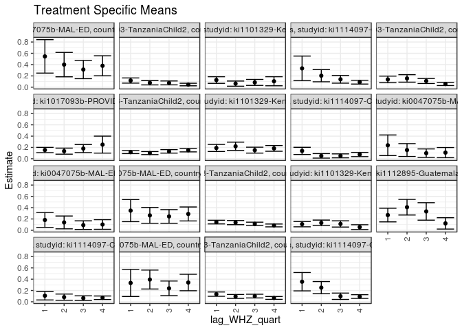

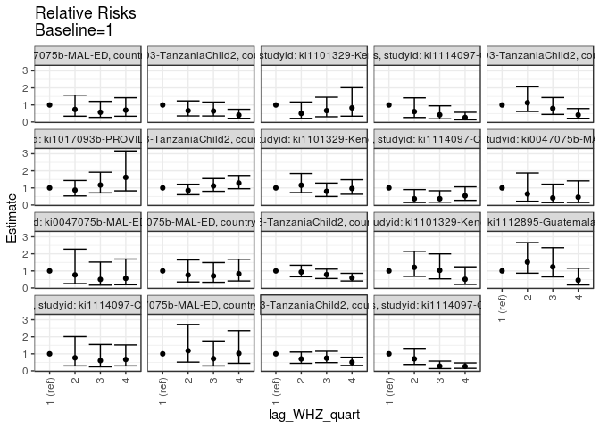

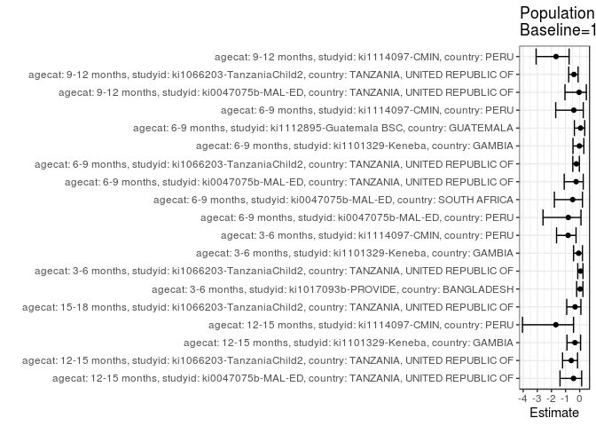

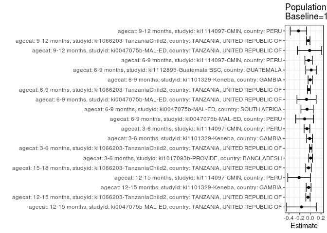

## Results Table

### Parameter: TSM

| agecat | studyid | country | intervention_level | baseline_level | estimate | ci_lower | ci_upper |
| --- | --- | --- | --- | --- | --- | --- | --- |
| 3-6 months | ki1017093b-PROVIDE | BANGLADESH | 1 | NA | 0.1545064 | 0.1080541 | 0.2009587 |
| 3-6 months | ki1017093b-PROVIDE | BANGLADESH | 2 | NA | 0.1346154 | 0.0810053 | 0.1882254 |
| 3-6 months | ki1017093b-PROVIDE | BANGLADESH | 3 | NA | 0.1801802 | 0.1086140 | 0.2517464 |
| 3-6 months | ki1017093b-PROVIDE | BANGLADESH | 4 | NA | 0.2500000 | 0.0998303 | 0.4001697 |
| 3-6 months | ki1066203-TanzaniaChild2 | TANZANIA, UNITED REPUBLIC OF | 1 | NA | 0.1173963 | 0.0906152 | 0.1441774 |
| 3-6 months | ki1066203-TanzaniaChild2 | TANZANIA, UNITED REPUBLIC OF | 2 | NA | 0.1002161 | 0.0733015 | 0.1271308 |
| 3-6 months | ki1066203-TanzaniaChild2 | TANZANIA, UNITED REPUBLIC OF | 3 | NA | 0.1307459 | 0.0997835 | 0.1617083 |
| 3-6 months | ki1066203-TanzaniaChild2 | TANZANIA, UNITED REPUBLIC OF | 4 | NA | 0.1506271 | 0.1214895 | 0.1797647 |
| 3-6 months | ki1101329-Keneba | GAMBIA | 1 | NA | 0.1906327 | 0.1281745 | 0.2530909 |
| 3-6 months | ki1101329-Keneba | GAMBIA | 2 | NA | 0.2201927 | 0.1463101 | 0.2940753 |
| 3-6 months | ki1101329-Keneba | GAMBIA | 3 | NA | 0.1518928 | 0.0995812 | 0.2042045 |
| 3-6 months | ki1101329-Keneba | GAMBIA | 4 | NA | 0.1835231 | 0.1324458 | 0.2346004 |
| 3-6 months | ki1114097-CMIN | PERU | 1 | NA | 0.1391304 | 0.0758228 | 0.2024381 |
| 3-6 months | ki1114097-CMIN | PERU | 2 | NA | 0.0508475 | 0.0111752 | 0.0905197 |
| 3-6 months | ki1114097-CMIN | PERU | 3 | NA | 0.0512821 | 0.0166391 | 0.0859250 |
| 3-6 months | ki1114097-CMIN | PERU | 4 | NA | 0.0748663 | 0.0371134 | 0.1126192 |
| 6-9 months | ki0047075b-MAL-ED | PERU | 1 | NA | 0.2380952 | 0.0553827 | 0.4208078 |
| 6-9 months | ki0047075b-MAL-ED | PERU | 2 | NA | 0.1538462 | 0.0402698 | 0.2674225 |
| 6-9 months | ki0047075b-MAL-ED | PERU | 3 | NA | 0.0983607 | 0.0234033 | 0.1733181 |
| 6-9 months | ki0047075b-MAL-ED | PERU | 4 | NA | 0.1086957 | 0.0184778 | 0.1989135 |
| 6-9 months | ki0047075b-MAL-ED | SOUTH AFRICA | 1 | NA | 0.1818182 | 0.0498426 | 0.3137937 |
| 6-9 months | ki0047075b-MAL-ED | SOUTH AFRICA | 2 | NA | 0.1388889 | 0.0255917 | 0.2521860 |
| 6-9 months | ki0047075b-MAL-ED | SOUTH AFRICA | 3 | NA | 0.0909091 | 0.0147130 | 0.1671052 |
| 6-9 months | ki0047075b-MAL-ED | SOUTH AFRICA | 4 | NA | 0.1020408 | 0.0170398 | 0.1870418 |
| 6-9 months | ki0047075b-MAL-ED | TANZANIA, UNITED REPUBLIC OF | 1 | NA | 0.3478261 | 0.1525759 | 0.5430763 |
| 6-9 months | ki0047075b-MAL-ED | TANZANIA, UNITED REPUBLIC OF | 2 | NA | 0.2631579 | 0.1227161 | 0.4035997 |
| 6-9 months | ki0047075b-MAL-ED | TANZANIA, UNITED REPUBLIC OF | 3 | NA | 0.2448980 | 0.1241193 | 0.3656766 |
| 6-9 months | ki0047075b-MAL-ED | TANZANIA, UNITED REPUBLIC OF | 4 | NA | 0.2884615 | 0.1649424 | 0.4119806 |
| 6-9 months | ki1066203-TanzaniaChild2 | TANZANIA, UNITED REPUBLIC OF | 1 | NA | 0.1448078 | 0.1121213 | 0.1774943 |
| 6-9 months | ki1066203-TanzaniaChild2 | TANZANIA, UNITED REPUBLIC OF | 2 | NA | 0.1355167 | 0.0988518 | 0.1721816 |
| 6-9 months | ki1066203-TanzaniaChild2 | TANZANIA, UNITED REPUBLIC OF | 3 | NA | 0.1131089 | 0.0832499 | 0.1429679 |
| 6-9 months | ki1066203-TanzaniaChild2 | TANZANIA, UNITED REPUBLIC OF | 4 | NA | 0.0856979 | 0.0604761 | 0.1109197 |
| 6-9 months | ki1101329-Keneba | GAMBIA | 1 | NA | 0.1084337 | 0.0610940 | 0.1557735 |
| 6-9 months | ki1101329-Keneba | GAMBIA | 2 | NA | 0.1311475 | 0.0821980 | 0.1800971 |
| 6-9 months | ki1101329-Keneba | GAMBIA | 3 | NA | 0.1120000 | 0.0566674 | 0.1673326 |
| 6-9 months | ki1101329-Keneba | GAMBIA | 4 | NA | 0.0550459 | 0.0121935 | 0.0978983 |
| 6-9 months | ki1112895-Guatemala BSC | GUATEMALA | 1 | NA | 0.2692308 | 0.1483319 | 0.3901296 |
| 6-9 months | ki1112895-Guatemala BSC | GUATEMALA | 2 | NA | 0.4081633 | 0.2701594 | 0.5461672 |
| 6-9 months | ki1112895-Guatemala BSC | GUATEMALA | 3 | NA | 0.3333333 | 0.1789096 | 0.4877570 |
| 6-9 months | ki1112895-Guatemala BSC | GUATEMALA | 4 | NA | 0.1219512 | 0.0215054 | 0.2223971 |
| 6-9 months | ki1114097-CMIN | PERU | 1 | NA | 0.1076923 | 0.0322656 | 0.1831190 |
| 6-9 months | ki1114097-CMIN | PERU | 2 | NA | 0.0824742 | 0.0276826 | 0.1372659 |
| 6-9 months | ki1114097-CMIN | PERU | 3 | NA | 0.0647482 | 0.0238030 | 0.1056934 |
| 6-9 months | ki1114097-CMIN | PERU | 4 | NA | 0.0716981 | 0.0406091 | 0.1027872 |
| 9-12 months | ki0047075b-MAL-ED | TANZANIA, UNITED REPUBLIC OF | 1 | NA | 0.3333333 | 0.0938583 | 0.5728083 |
| 9-12 months | ki0047075b-MAL-ED | TANZANIA, UNITED REPUBLIC OF | 2 | NA | 0.3939394 | 0.2265886 | 0.5612902 |
| 9-12 months | ki0047075b-MAL-ED | TANZANIA, UNITED REPUBLIC OF | 3 | NA | 0.2380952 | 0.1087909 | 0.3673996 |
| 9-12 months | ki0047075b-MAL-ED | TANZANIA, UNITED REPUBLIC OF | 4 | NA | 0.3414634 | 0.1957558 | 0.4871710 |
| 9-12 months | ki1066203-TanzaniaChild2 | TANZANIA, UNITED REPUBLIC OF | 1 | NA | 0.1354186 | 0.0971781 | 0.1736590 |
| 9-12 months | ki1066203-TanzaniaChild2 | TANZANIA, UNITED REPUBLIC OF | 2 | NA | 0.0947115 | 0.0605853 | 0.1288376 |
| 9-12 months | ki1066203-TanzaniaChild2 | TANZANIA, UNITED REPUBLIC OF | 3 | NA | 0.1010278 | 0.0680652 | 0.1339904 |
| 9-12 months | ki1066203-TanzaniaChild2 | TANZANIA, UNITED REPUBLIC OF | 4 | NA | 0.0683590 | 0.0433131 | 0.0934049 |
| 9-12 months | ki1114097-CMIN | PERU | 1 | NA | 0.3554021 | 0.1930324 | 0.5177717 |
| 9-12 months | ki1114097-CMIN | PERU | 2 | NA | 0.2507711 | 0.1433810 | 0.3581612 |
| 9-12 months | ki1114097-CMIN | PERU | 3 | NA | 0.0979537 | 0.0419649 | 0.1539426 |
| 9-12 months | ki1114097-CMIN | PERU | 4 | NA | 0.0928782 | 0.0599607 | 0.1257957 |
| 12-15 months | ki0047075b-MAL-ED | TANZANIA, UNITED REPUBLIC OF | 1 | NA | 0.5454545 | 0.2495900 | 0.8413191 |
| 12-15 months | ki0047075b-MAL-ED | TANZANIA, UNITED REPUBLIC OF | 2 | NA | 0.4000000 | 0.1841202 | 0.6158798 |
| 12-15 months | ki0047075b-MAL-ED | TANZANIA, UNITED REPUBLIC OF | 3 | NA | 0.3125000 | 0.1510241 | 0.4739759 |
| 12-15 months | ki0047075b-MAL-ED | TANZANIA, UNITED REPUBLIC OF | 4 | NA | 0.3793103 | 0.2017455 | 0.5568752 |
| 12-15 months | ki1066203-TanzaniaChild2 | TANZANIA, UNITED REPUBLIC OF | 1 | NA | 0.1182577 | 0.0721791 | 0.1643362 |
| 12-15 months | ki1066203-TanzaniaChild2 | TANZANIA, UNITED REPUBLIC OF | 2 | NA | 0.0785367 | 0.0405504 | 0.1165230 |
| 12-15 months | ki1066203-TanzaniaChild2 | TANZANIA, UNITED REPUBLIC OF | 3 | NA | 0.0760019 | 0.0414966 | 0.1105072 |
| 12-15 months | ki1066203-TanzaniaChild2 | TANZANIA, UNITED REPUBLIC OF | 4 | NA | 0.0476709 | 0.0249226 | 0.0704193 |
| 12-15 months | ki1101329-Keneba | GAMBIA | 1 | NA | 0.1269841 | 0.0687747 | 0.1851936 |
| 12-15 months | ki1101329-Keneba | GAMBIA | 2 | NA | 0.0636364 | 0.0179621 | 0.1093106 |
| 12-15 months | ki1101329-Keneba | GAMBIA | 3 | NA | 0.0849057 | 0.0317755 | 0.1380358 |
| 12-15 months | ki1101329-Keneba | GAMBIA | 4 | NA | 0.1052632 | 0.0254928 | 0.1850335 |
| 12-15 months | ki1114097-CMIN | PERU | 1 | NA | 0.3333333 | 0.1153183 | 0.5513484 |
| 12-15 months | ki1114097-CMIN | PERU | 2 | NA | 0.2037037 | 0.0961640 | 0.3112434 |
| 12-15 months | ki1114097-CMIN | PERU | 3 | NA | 0.1400000 | 0.0719164 | 0.2080836 |
| 12-15 months | ki1114097-CMIN | PERU | 4 | NA | 0.0892857 | 0.0558483 | 0.1227231 |
| 15-18 months | ki1066203-TanzaniaChild2 | TANZANIA, UNITED REPUBLIC OF | 1 | NA | 0.1378141 | 0.0792158 | 0.1964124 |
| 15-18 months | ki1066203-TanzaniaChild2 | TANZANIA, UNITED REPUBLIC OF | 2 | NA | 0.1556144 | 0.0891398 | 0.2220891 |
| 15-18 months | ki1066203-TanzaniaChild2 | TANZANIA, UNITED REPUBLIC OF | 3 | NA | 0.1100838 | 0.0658228 | 0.1543447 |
| 15-18 months | ki1066203-TanzaniaChild2 | TANZANIA, UNITED REPUBLIC OF | 4 | NA | 0.0571161 | 0.0295346 | 0.0846977 |

### Parameter: E(Y)

| agecat | studyid | country | intervention_level | baseline_level | estimate | ci_lower | ci_upper |
| --- | --- | --- | --- | --- | --- | --- | --- |
| 3-6 months | ki1017093b-PROVIDE | BANGLADESH | NA | NA | 0.1597744 | 0.1286105 | 0.1909384 |
| 3-6 months | ki1066203-TanzaniaChild2 | TANZANIA, UNITED REPUBLIC OF | NA | NA | 0.1258405 | 0.1115904 | 0.1400906 |
| 3-6 months | ki1101329-Keneba | GAMBIA | NA | NA | 0.1775417 | 0.1483445 | 0.2067390 |
| 3-6 months | ki1114097-CMIN | PERU | NA | NA | 0.0763889 | 0.0546782 | 0.0980996 |
| 6-9 months | ki0047075b-MAL-ED | PERU | NA | NA | 0.1317365 | 0.0802880 | 0.1831851 |
| 6-9 months | ki0047075b-MAL-ED | SOUTH AFRICA | NA | NA | 0.1213873 | 0.0725817 | 0.1701928 |
| 6-9 months | ki0047075b-MAL-ED | TANZANIA, UNITED REPUBLIC OF | NA | NA | 0.2777778 | 0.2085916 | 0.3469640 |
| 6-9 months | ki1066203-TanzaniaChild2 | TANZANIA, UNITED REPUBLIC OF | NA | NA | 0.1173317 | 0.1019339 | 0.1327295 |
| 6-9 months | ki1101329-Keneba | GAMBIA | NA | NA | 0.1063465 | 0.0813008 | 0.1313922 |
| 6-9 months | ki1112895-Guatemala BSC | GUATEMALA | NA | NA | 0.2865169 | 0.2199085 | 0.3531252 |
| 6-9 months | ki1114097-CMIN | PERU | NA | NA | 0.0759717 | 0.0541247 | 0.0978188 |
| 9-12 months | ki0047075b-MAL-ED | TANZANIA, UNITED REPUBLIC OF | NA | NA | 0.3206107 | 0.2403829 | 0.4008385 |
| 9-12 months | ki1066203-TanzaniaChild2 | TANZANIA, UNITED REPUBLIC OF | NA | NA | 0.0962733 | 0.0801583 | 0.1123883 |
| 9-12 months | ki1114097-CMIN | PERU | NA | NA | 0.1329480 | 0.1037100 | 0.1621859 |
| 12-15 months | ki0047075b-MAL-ED | TANZANIA, UNITED REPUBLIC OF | NA | NA | 0.3804348 | 0.2806852 | 0.4801843 |
| 12-15 months | ki1066203-TanzaniaChild2 | TANZANIA, UNITED REPUBLIC OF | NA | NA | 0.0740741 | 0.0573677 | 0.0907805 |
| 12-15 months | ki1101329-Keneba | GAMBIA | NA | NA | 0.0952381 | 0.0663992 | 0.1240770 |
| 12-15 months | ki1114097-CMIN | PERU | NA | NA | 0.1238938 | 0.0934875 | 0.1543001 |
| 15-18 months | ki1066203-TanzaniaChild2 | TANZANIA, UNITED REPUBLIC OF | NA | NA | 0.1041096 | 0.0819400 | 0.1262792 |

### Parameter: RR

| agecat | studyid | country | intervention_level | baseline_level | estimate | ci_lower | ci_upper |
| --- | --- | --- | --- | --- | --- | --- | --- |
| 3-6 months | ki1017093b-PROVIDE | BANGLADESH | 1 | 1 | 1.0000000 | 1.0000000 | 1.0000000 |
| 3-6 months | ki1017093b-PROVIDE | BANGLADESH | 2 | 1 | 0.8712607 | 0.5289808 | 1.4350147 |
| 3-6 months | ki1017093b-PROVIDE | BANGLADESH | 3 | 1 | 1.1661662 | 0.7086264 | 1.9191263 |
| 3-6 months | ki1017093b-PROVIDE | BANGLADESH | 4 | 1 | 1.6180556 | 0.8265516 | 3.1675018 |
| 3-6 months | ki1066203-TanzaniaChild2 | TANZANIA, UNITED REPUBLIC OF | 1 | 1 | 1.0000000 | 1.0000000 | 1.0000000 |
| 3-6 months | ki1066203-TanzaniaChild2 | TANZANIA, UNITED REPUBLIC OF | 2 | 1 | 0.8536565 | 0.6001169 | 1.2143124 |
| 3-6 months | ki1066203-TanzaniaChild2 | TANZANIA, UNITED REPUBLIC OF | 3 | 1 | 1.1137138 | 0.8015107 | 1.5475257 |
| 3-6 months | ki1066203-TanzaniaChild2 | TANZANIA, UNITED REPUBLIC OF | 4 | 1 | 1.2830650 | 0.9513433 | 1.7304540 |
| 3-6 months | ki1101329-Keneba | GAMBIA | 1 | 1 | 1.0000000 | 1.0000000 | 1.0000000 |
| 3-6 months | ki1101329-Keneba | GAMBIA | 2 | 1 | 1.1550625 | 0.7226017 | 1.8463413 |
| 3-6 months | ki1101329-Keneba | GAMBIA | 3 | 1 | 0.7967826 | 0.4954791 | 1.2813102 |
| 3-6 months | ki1101329-Keneba | GAMBIA | 4 | 1 | 0.9627049 | 0.6260978 | 1.4802811 |
| 3-6 months | ki1114097-CMIN | PERU | 1 | 1 | 1.0000000 | 1.0000000 | 1.0000000 |
| 3-6 months | ki1114097-CMIN | PERU | 2 | 1 | 0.3654661 | 0.1481109 | 0.9017935 |
| 3-6 months | ki1114097-CMIN | PERU | 3 | 1 | 0.3685897 | 0.1632353 | 0.8322857 |
| 3-6 months | ki1114097-CMIN | PERU | 4 | 1 | 0.5381016 | 0.2728250 | 1.0613152 |
| 6-9 months | ki0047075b-MAL-ED | PERU | 1 | 1 | 1.0000000 | 1.0000000 | 1.0000000 |
| 6-9 months | ki0047075b-MAL-ED | PERU | 2 | 1 | 0.6461538 | 0.2227813 | 1.8741015 |
| 6-9 months | ki0047075b-MAL-ED | PERU | 3 | 1 | 0.4131148 | 0.1400820 | 1.2183139 |
| 6-9 months | ki0047075b-MAL-ED | PERU | 4 | 1 | 0.4565217 | 0.1474131 | 1.4137963 |
| 6-9 months | ki0047075b-MAL-ED | SOUTH AFRICA | 1 | 1 | 1.0000000 | 1.0000000 | 1.0000000 |
| 6-9 months | ki0047075b-MAL-ED | SOUTH AFRICA | 2 | 1 | 0.7638889 | 0.2563368 | 2.2764049 |
| 6-9 months | ki0047075b-MAL-ED | SOUTH AFRICA | 3 | 1 | 0.5000000 | 0.1649810 | 1.5153263 |
| 6-9 months | ki0047075b-MAL-ED | SOUTH AFRICA | 4 | 1 | 0.5612245 | 0.1859037 | 1.6942799 |
| 6-9 months | ki0047075b-MAL-ED | TANZANIA, UNITED REPUBLIC OF | 1 | 1 | 1.0000000 | 1.0000000 | 1.0000000 |
| 6-9 months | ki0047075b-MAL-ED | TANZANIA, UNITED REPUBLIC OF | 2 | 1 | 0.7565789 | 0.3487173 | 1.6414778 |
| 6-9 months | ki0047075b-MAL-ED | TANZANIA, UNITED REPUBLIC OF | 3 | 1 | 0.7040816 | 0.3335115 | 1.4863985 |
| 6-9 months | ki0047075b-MAL-ED | TANZANIA, UNITED REPUBLIC OF | 4 | 1 | 0.8293269 | 0.4093603 | 1.6801412 |
| 6-9 months | ki1066203-TanzaniaChild2 | TANZANIA, UNITED REPUBLIC OF | 1 | 1 | 1.0000000 | 1.0000000 | 1.0000000 |
| 6-9 months | ki1066203-TanzaniaChild2 | TANZANIA, UNITED REPUBLIC OF | 2 | 1 | 0.9358384 | 0.6578870 | 1.3312218 |
| 6-9 months | ki1066203-TanzaniaChild2 | TANZANIA, UNITED REPUBLIC OF | 3 | 1 | 0.7810970 | 0.5519324 | 1.1054116 |
| 6-9 months | ki1066203-TanzaniaChild2 | TANZANIA, UNITED REPUBLIC OF | 4 | 1 | 0.5918043 | 0.4083735 | 0.8576274 |
| 6-9 months | ki1101329-Keneba | GAMBIA | 1 | 1 | 1.0000000 | 1.0000000 | 1.0000000 |
| 6-9 months | ki1101329-Keneba | GAMBIA | 2 | 1 | 1.2094718 | 0.6810003 | 2.1480491 |
| 6-9 months | ki1101329-Keneba | GAMBIA | 3 | 1 | 1.0328889 | 0.5342237 | 1.9970277 |
| 6-9 months | ki1101329-Keneba | GAMBIA | 4 | 1 | 0.5076453 | 0.2079372 | 1.2393344 |
| 6-9 months | ki1112895-Guatemala BSC | GUATEMALA | 1 | 1 | 1.0000000 | 1.0000000 | 1.0000000 |
| 6-9 months | ki1112895-Guatemala BSC | GUATEMALA | 2 | 1 | 1.5160350 | 0.8641484 | 2.6596843 |
| 6-9 months | ki1112895-Guatemala BSC | GUATEMALA | 3 | 1 | 1.2380952 | 0.6494595 | 2.3602392 |
| 6-9 months | ki1112895-Guatemala BSC | GUATEMALA | 4 | 1 | 0.4529617 | 0.1772735 | 1.1573883 |
| 6-9 months | ki1114097-CMIN | PERU | 1 | 1 | 1.0000000 | 1.0000000 | 1.0000000 |
| 6-9 months | ki1114097-CMIN | PERU | 2 | 1 | 0.7658321 | 0.2916662 | 2.0108566 |
| 6-9 months | ki1114097-CMIN | PERU | 3 | 1 | 0.6012333 | 0.2340064 | 1.5447503 |
| 6-9 months | ki1114097-CMIN | PERU | 4 | 1 | 0.6657682 | 0.2921276 | 1.5173070 |
| 9-12 months | ki0047075b-MAL-ED | TANZANIA, UNITED REPUBLIC OF | 1 | 1 | 1.0000000 | 1.0000000 | 1.0000000 |
| 9-12 months | ki0047075b-MAL-ED | TANZANIA, UNITED REPUBLIC OF | 2 | 1 | 1.1818182 | 0.5129524 | 2.7228534 |
| 9-12 months | ki0047075b-MAL-ED | TANZANIA, UNITED REPUBLIC OF | 3 | 1 | 0.7142857 | 0.2902346 | 1.7579022 |
| 9-12 months | ki0047075b-MAL-ED | TANZANIA, UNITED REPUBLIC OF | 4 | 1 | 1.0243902 | 0.4441921 | 2.3624360 |
| 9-12 months | ki1066203-TanzaniaChild2 | TANZANIA, UNITED REPUBLIC OF | 1 | 1 | 1.0000000 | 1.0000000 | 1.0000000 |
| 9-12 months | ki1066203-TanzaniaChild2 | TANZANIA, UNITED REPUBLIC OF | 2 | 1 | 0.6993979 | 0.4424662 | 1.1055247 |
| 9-12 months | ki1066203-TanzaniaChild2 | TANZANIA, UNITED REPUBLIC OF | 3 | 1 | 0.7460409 | 0.4843184 | 1.1491966 |
| 9-12 months | ki1066203-TanzaniaChild2 | TANZANIA, UNITED REPUBLIC OF | 4 | 1 | 0.5047979 | 0.3178016 | 0.8018239 |
| 9-12 months | ki1114097-CMIN | PERU | 1 | 1 | 1.0000000 | 1.0000000 | 1.0000000 |
| 9-12 months | ki1114097-CMIN | PERU | 2 | 1 | 0.7055983 | 0.3774006 | 1.3192056 |
| 9-12 months | ki1114097-CMIN | PERU | 3 | 1 | 0.2756139 | 0.1327505 | 0.5722239 |
| 9-12 months | ki1114097-CMIN | PERU | 4 | 1 | 0.2613326 | 0.1465965 | 0.4658689 |
| 12-15 months | ki0047075b-MAL-ED | TANZANIA, UNITED REPUBLIC OF | 1 | 1 | 1.0000000 | 1.0000000 | 1.0000000 |
| 12-15 months | ki0047075b-MAL-ED | TANZANIA, UNITED REPUBLIC OF | 2 | 1 | 0.7333333 | 0.3411851 | 1.5762053 |
| 12-15 months | ki0047075b-MAL-ED | TANZANIA, UNITED REPUBLIC OF | 3 | 1 | 0.5729167 | 0.2708578 | 1.2118296 |
| 12-15 months | ki0047075b-MAL-ED | TANZANIA, UNITED REPUBLIC OF | 4 | 1 | 0.6954023 | 0.3396786 | 1.4236529 |
| 12-15 months | ki1066203-TanzaniaChild2 | TANZANIA, UNITED REPUBLIC OF | 1 | 1 | 1.0000000 | 1.0000000 | 1.0000000 |
| 12-15 months | ki1066203-TanzaniaChild2 | TANZANIA, UNITED REPUBLIC OF | 2 | 1 | 0.6641153 | 0.3567984 | 1.2361296 |
| 12-15 months | ki1066203-TanzaniaChild2 | TANZANIA, UNITED REPUBLIC OF | 3 | 1 | 0.6426804 | 0.3531213 | 1.1696776 |
| 12-15 months | ki1066203-TanzaniaChild2 | TANZANIA, UNITED REPUBLIC OF | 4 | 1 | 0.4031107 | 0.2176226 | 0.7466976 |
| 12-15 months | ki1101329-Keneba | GAMBIA | 1 | 1 | 1.0000000 | 1.0000000 | 1.0000000 |
| 12-15 months | ki1101329-Keneba | GAMBIA | 2 | 1 | 0.5011364 | 0.2138437 | 1.1743982 |
| 12-15 months | ki1101329-Keneba | GAMBIA | 3 | 1 | 0.6686321 | 0.3078279 | 1.4523340 |
| 12-15 months | ki1101329-Keneba | GAMBIA | 4 | 1 | 0.8289474 | 0.3418878 | 2.0098808 |
| 12-15 months | ki1114097-CMIN | PERU | 1 | 1 | 1.0000000 | 1.0000000 | 1.0000000 |
| 12-15 months | ki1114097-CMIN | PERU | 2 | 1 | 0.6111111 | 0.2636854 | 1.4162967 |
| 12-15 months | ki1114097-CMIN | PERU | 3 | 1 | 0.4200000 | 0.1859030 | 0.9488821 |
| 12-15 months | ki1114097-CMIN | PERU | 4 | 1 | 0.2678571 | 0.1260628 | 0.5691407 |
| 15-18 months | ki1066203-TanzaniaChild2 | TANZANIA, UNITED REPUBLIC OF | 1 | 1 | 1.0000000 | 1.0000000 | 1.0000000 |
| 15-18 months | ki1066203-TanzaniaChild2 | TANZANIA, UNITED REPUBLIC OF | 2 | 1 | 1.1291618 | 0.6178046 | 2.0637696 |
| 15-18 months | ki1066203-TanzaniaChild2 | TANZANIA, UNITED REPUBLIC OF | 3 | 1 | 0.7987842 | 0.4448169 | 1.4344246 |
| 15-18 months | ki1066203-TanzaniaChild2 | TANZANIA, UNITED REPUBLIC OF | 4 | 1 | 0.4144433 | 0.2177946 | 0.7886481 |

### Parameter: PAR

| agecat | studyid | country | intervention_level | baseline_level | estimate | ci_lower | ci_upper |
| --- | --- | --- | --- | --- | --- | --- | --- |
| 3-6 months | ki1017093b-PROVIDE | BANGLADESH | 1 | NA | 0.0052680 | -0.0299299 | 0.0404659 |
| 3-6 months | ki1066203-TanzaniaChild2 | TANZANIA, UNITED REPUBLIC OF | 1 | NA | 0.0084442 | -0.0147114 | 0.0315999 |
| 3-6 months | ki1101329-Keneba | GAMBIA | 1 | NA | -0.0130910 | -0.0677623 | 0.0415803 |
| 3-6 months | ki1114097-CMIN | PERU | 1 | NA | -0.0627415 | -0.1163965 | -0.0090866 |
| 6-9 months | ki0047075b-MAL-ED | PERU | 1 | NA | -0.1063587 | -0.2725961 | 0.0598787 |
| 6-9 months | ki0047075b-MAL-ED | SOUTH AFRICA | 1 | NA | -0.0604309 | -0.1751248 | 0.0542630 |
| 6-9 months | ki0047075b-MAL-ED | TANZANIA, UNITED REPUBLIC OF | 1 | NA | -0.0700483 | -0.2491696 | 0.1090729 |
| 6-9 months | ki1066203-TanzaniaChild2 | TANZANIA, UNITED REPUBLIC OF | 1 | NA | -0.0274761 | -0.0546898 | -0.0002623 |
| 6-9 months | ki1101329-Keneba | GAMBIA | 1 | NA | -0.0020873 | -0.0419887 | 0.0378142 |
| 6-9 months | ki1112895-Guatemala BSC | GUATEMALA | 1 | NA | 0.0172861 | -0.0852478 | 0.1198200 |
| 6-9 months | ki1114097-CMIN | PERU | 1 | NA | -0.0317206 | -0.1014327 | 0.0379915 |
| 9-12 months | ki0047075b-MAL-ED | TANZANIA, UNITED REPUBLIC OF | 1 | NA | -0.0127226 | -0.2377817 | 0.2123364 |
| 9-12 months | ki1066203-TanzaniaChild2 | TANZANIA, UNITED REPUBLIC OF | 1 | NA | -0.0391453 | -0.0712405 | -0.0070500 |
| 9-12 months | ki1114097-CMIN | PERU | 1 | NA | -0.2224541 | -0.3759891 | -0.0689191 |
| 12-15 months | ki0047075b-MAL-ED | TANZANIA, UNITED REPUBLIC OF | 1 | NA | -0.1650198 | -0.4417025 | 0.1116629 |
| 12-15 months | ki1066203-TanzaniaChild2 | TANZANIA, UNITED REPUBLIC OF | 1 | NA | -0.0441836 | -0.0836979 | -0.0046693 |
| 12-15 months | ki1101329-Keneba | GAMBIA | 1 | NA | -0.0317460 | -0.0773533 | 0.0138612 |
| 12-15 months | ki1114097-CMIN | PERU | 1 | NA | -0.2094395 | -0.4207911 | 0.0019121 |
| 15-18 months | ki1066203-TanzaniaChild2 | TANZANIA, UNITED REPUBLIC OF | 1 | NA | -0.0337045 | -0.0851851 | 0.0177760 |

### Parameter: PAF

| agecat | studyid | country | intervention_level | baseline_level | estimate | ci_lower | ci_upper |
| --- | --- | --- | --- | --- | --- | --- | --- |
| 3-6 months | ki1017093b-PROVIDE | BANGLADESH | 1 | NA | 0.0329715 | -0.2143632 | 0.2299304 |
| 3-6 months | ki1066203-TanzaniaChild2 | TANZANIA, UNITED REPUBLIC OF | 1 | NA | 0.0671026 | -0.1361890 | 0.2340204 |
| 3-6 months | ki1101329-Keneba | GAMBIA | 1 | NA | -0.0737347 | -0.4303841 | 0.1939884 |
| 3-6 months | ki1114097-CMIN | PERU | 1 | NA | -0.8213439 | -1.6380485 | -0.2574801 |
| 6-9 months | ki0047075b-MAL-ED | PERU | 1 | NA | -0.8073593 | -2.5971848 | 0.0919155 |
| 6-9 months | ki0047075b-MAL-ED | SOUTH AFRICA | 1 | NA | -0.4978355 | -1.7912392 | 0.1962311 |
| 6-9 months | ki0047075b-MAL-ED | TANZANIA, UNITED REPUBLIC OF | 1 | NA | -0.2521739 | -1.0954428 | 0.2517384 |
| 6-9 months | ki1066203-TanzaniaChild2 | TANZANIA, UNITED REPUBLIC OF | 1 | NA | -0.2341742 | -0.4877776 | -0.0237994 |
| 6-9 months | ki1101329-Keneba | GAMBIA | 1 | NA | -0.0196269 | -0.4731399 | 0.2942700 |
| 6-9 months | ki1112895-Guatemala BSC | GUATEMALA | 1 | NA | 0.0603318 | -0.3751187 | 0.3578909 |
| 6-9 months | ki1114097-CMIN | PERU | 1 | NA | -0.4175313 | -1.6965668 | 0.2548321 |
| 9-12 months | ki0047075b-MAL-ED | TANZANIA, UNITED REPUBLIC OF | 1 | NA | -0.0396825 | -1.0423300 | 0.4707321 |
| 9-12 months | ki1066203-TanzaniaChild2 | TANZANIA, UNITED REPUBLIC OF | 1 | NA | -0.4066057 | -0.7771926 | -0.1132950 |
| 9-12 months | ki1114097-CMIN | PERU | 1 | NA | -1.6732418 | -3.0856128 | -0.7491186 |
| 12-15 months | ki0047075b-MAL-ED | TANZANIA, UNITED REPUBLIC OF | 1 | NA | -0.4337662 | -1.3922951 | 0.1407057 |
| 12-15 months | ki1066203-TanzaniaChild2 | TANZANIA, UNITED REPUBLIC OF | 1 | NA | -0.5964787 | -1.2131840 | -0.1516188 |
| 12-15 months | ki1101329-Keneba | GAMBIA | 1 | NA | -0.3333333 | -0.8984803 | 0.0635785 |
| 12-15 months | ki1114097-CMIN | PERU | 1 | NA | -1.6904762 | -4.0494250 | -0.4335617 |
| 15-18 months | ki1066203-TanzaniaChild2 | TANZANIA, UNITED REPUBLIC OF | 1 | NA | -0.3237409 | -0.9173955 | 0.0861092 |